# QQ-plots in R vs SPSS

# Function for SPSS-type QQ-plot

The whole point of this demonstration was to pinpoint and explain the differences between a QQ-plot generated in R and SPSS, so it will no longer be a reason for confusion. Note, however, that SPSS offers a whole range of options to generate the plot. For example, you can select the method to assign probabilities to ranks and decide how to treat ties. The plots above used the default setting (Blom’s method and averaging across ties). Personally I like the SPSS version. That is why I implemented the function `qqnorm_spss` in the [`ryouready`](https://github.com/markheckmann/ryouready/) package, that accompanies the course. The formulae for the different methods to assign probabilities to ranks can be found in Castillo-Gutiérrez et al. (2012b). The implentation is a preliminary version that has not yet been thoroughly tested. You can find the code [here](https://github.com/markheckmann/ryouready/blob/master/R/qq-plot.R). Please report any bugs or suggestions for improvements (which are very welcome) in the github [*issues* section](https://github.com/markheckmann/ryouready/issues).

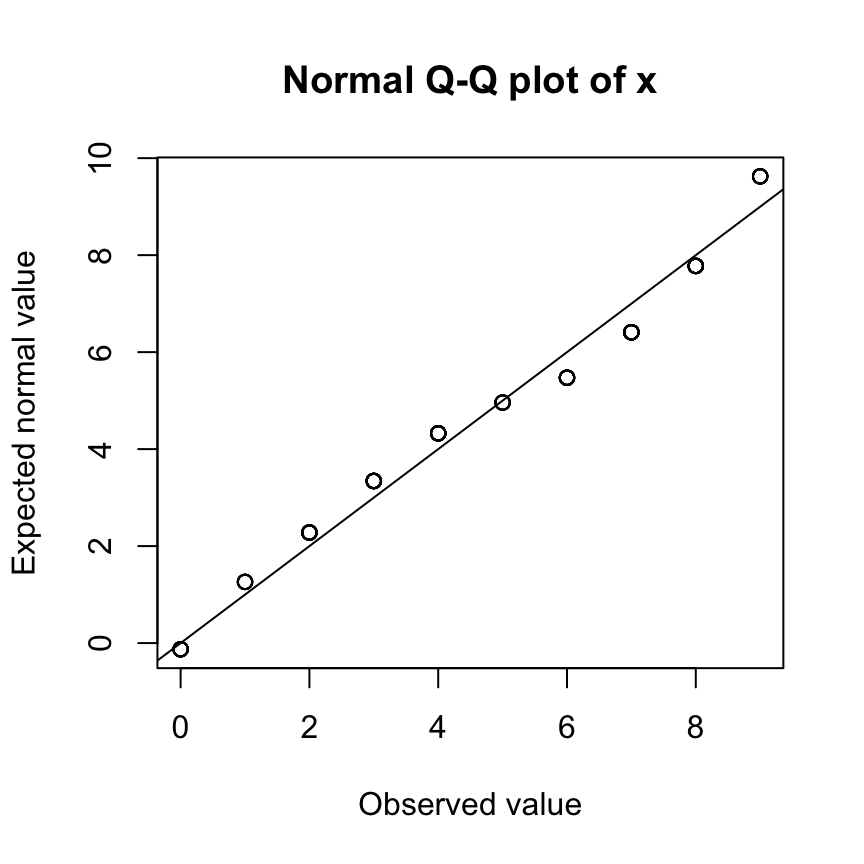

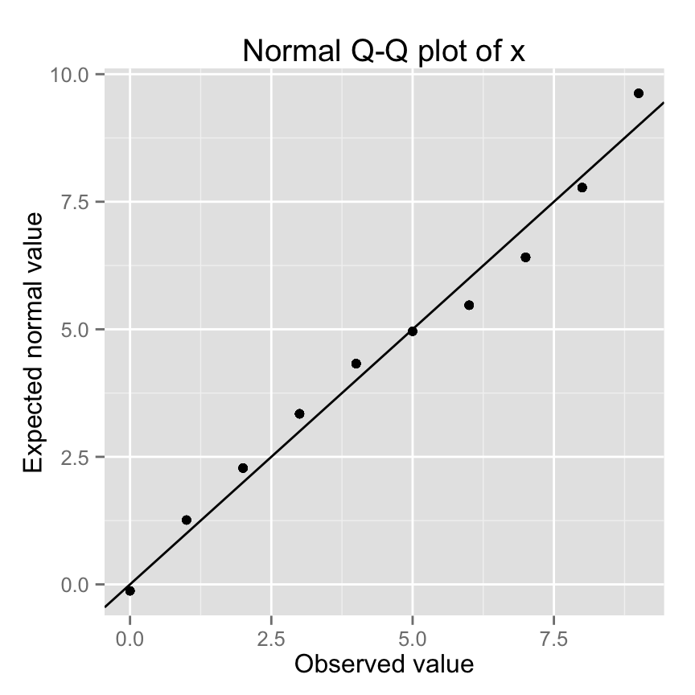

```r
library(devtools)
install_github("markheckmann/ryouready")                # install from github repo
library(ryouready)                                      # load package
library(ggplot2)
qq <- qqnorm_spss(x, method=1, ties.method="average")   # Blom's method with averaged ties
plot(qq)                                                # generate QQ-plot
ggplot(qq)                                              # use ggplot2 to generate QQ-plot
```

# Literature

- Blom, G. (1958). *Statistical Estimates and Transformed Beta Variables*. Wiley.
- Castillo-Gutiérrez, S., Lozano-Aguilera, E. D., & Estudillo-Martínez, M. D. (2012a). [A New Proposal to Adjust a Straight Line to a Normal Q-Q Plot](http://davidpublishing.org/show.html?8305). *Journal of Mathematics and System Science, 2*(5), 327–333.
- Castillo-Gutiérrez, S., Lozano-Aguilera, E., & Estudillo-Martínez, M. D. (2012b). [Selection of a Plotting Position for a Normal Q-Q Plot. R Script](http://davidpublishing.org/show.html?4874). *Journal of Communication and Computer, 9*(3), 243–250.
[^1]: *Technical sidenote*: Internally, `qqnorm` uses the function `ppoints` to generate the p-values. Type in `stats:::qqnorm.default` to the console to have a look at the code.